# Graph 2

These graphs show Google Trend values for two keyword search terms over time. They contain data for the District of Columbia metropolitan statistical area (MSA) and the United States as a whole. These graphs are illustrative of the potential of Google Trend data to provide insights on financial stress.

The data look at “food bank” and “payday loan” keyword searches for the past five years. This time period includes a recent exogenous shock: the federal shutdown. This event was reported to have significant financial impact on workers in the District of Columbia, causing them to have to visit food banks or seek costly loans.

```
Ignoring unknown parameters: model
```

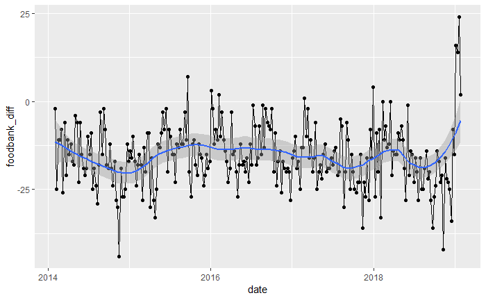

```r
food_dc <- google_dc_food[["interest_over_time"]]
food_all <- google_all_food[["interest_over_time"]]
food <- as.data.frame(food_dc) %>%
  left_join(., food_all, by = "date") %>%
  mutate(foodbank_diff = .$hits.x - .$hits.y)
ggplot(food, aes(date, foodbank_diff)) +
  geom_point() +
  geom_line() +
  geom_smooth(model=loess, span = .3)
```

This graph looks at the difference between U.S. hits and District of Columbia hits overtime for the keyword search “food bank.” It shows that the difference in food bank searches has remained most constant for the past five years with some variation. However, it shows that during the recent government shutdown, search for foodbanks in D.C. spiked by a significant amount, making this event appear unusal.

```
Ignoring unknown parameters: model
```

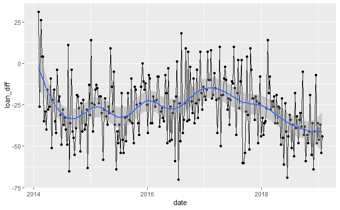

```r
loan_dc <- google_dc_loan[["interest_over_time"]]
loan_all <- google_all_loan[["interest_over_time"]]
loan <- as.data.frame(loan_dc) %>%
  left_join(., loan_all, by = "date") %>%
  mutate(loan_diff = .$hits.x - .$hits.y)
ggplot(loan, aes(date, loan_diff)) +
  geom_point() +
  geom_line() +
  geom_smooth(model =loess, span = .3)
```

This graph looks at the difference between U.S. hits and District of Columbia hits overtime for the keyword search “payday loans.: It shows that there was a relative spike in the District relative to the rest of the United States in 2017–during a political transition–but has been declining since. It shows no evidence that payday loan searches increased during the government shutdown.

Collectively, these graphs show the potential for identifying the effect of exogenous shocks in Google Trend data. If these differences can be validated, they show the potential of using Google Trend data to identify signals of financial stress in an early warning system. However, more work is necessary to determine what indicators of financial stress are more likely to appear when (i.e. why do loans spike in one period and food banks in another?).